# Cluster analysis with allometric data

```r
library(compbio4all)
```

## Cluster analysis

The PCA we did on the mammal sleep data didn’t indicate any interesting groups. Instead lets work with a famous dataset with known strong groups.

Read about these data here https://en.wikipedia.org/wiki/Iris_flower_data_set

You should defintely read this as further background on PCA and cluster analysis.

For more on PCA see https://rpubs.com/brouwern/veganpca

Notes on drawing dendrograms: http://www.sthda.com/english/wiki/beautiful-dendrogram-visualizations-in-r-5-must-known-methods-unsupervised-machine-learning#plot.dendrogram-function

## Preliminaries

### Download packages

Only do this once, then comment out of the script. You probably already did this in the previous Code Checkpoint.

```r
# install.packages("ggplot2")
# install.package("vegan")
```

### Load the libraries

```r
library(ggplot2)
library(vegan)
```

## PCA data exploration

```r
data(iris)
```

Scatterplot matrix

```r
panel.cor <- function(x, y, digits = 2, prefix = "", cex.cor, ...)
{
    usr <- par("usr"); on.exit(par(usr))
    par(usr = c(0, 1, 0, 1))
    r <- abs(cor(x, y))
    txt <- format(c(r, 0.123456789), digits = digits)[1]
    txt <- paste0(prefix, txt)
    if(missing(cex.cor)) cex.cor <- 0.8/strwidth(txt)
    text(0.5, 0.5, txt, cex = cex.cor * r)
}
```

When looking at a plot like this you should understand how to read it, what the correlations mean, what the red lines meanm, etc.

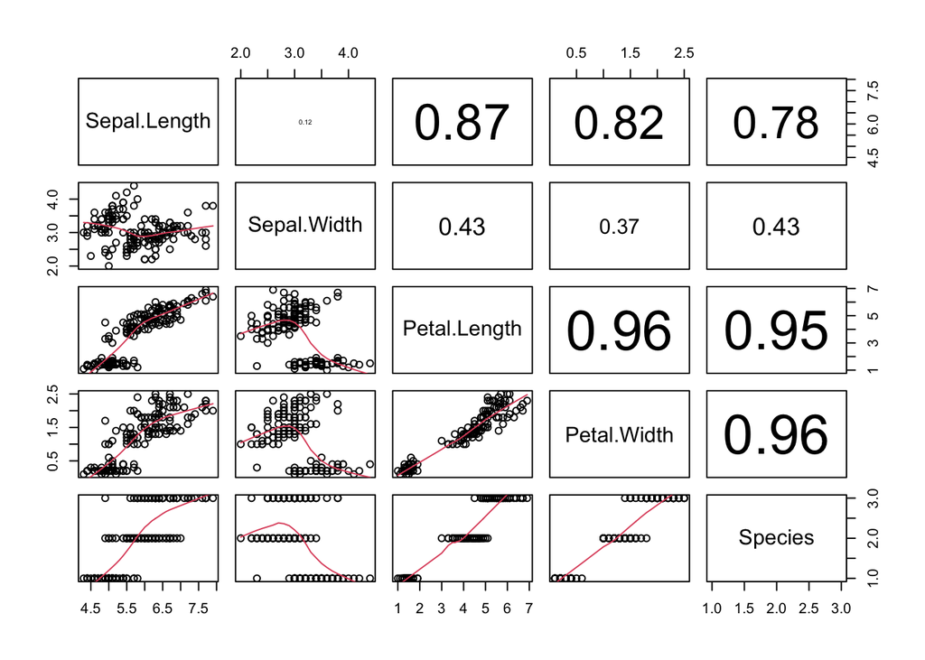

```r
plot(iris,upper.panel = panel.cor,
     panel = panel.smooth)
```

Run the PCA using rda()

```r
rda.out <- vegan::rda(iris[,-5], scale = TRUE)
```

This displays the 2D PCA plot without the arrows. For more info on what this code does, see the RPubs document linked above

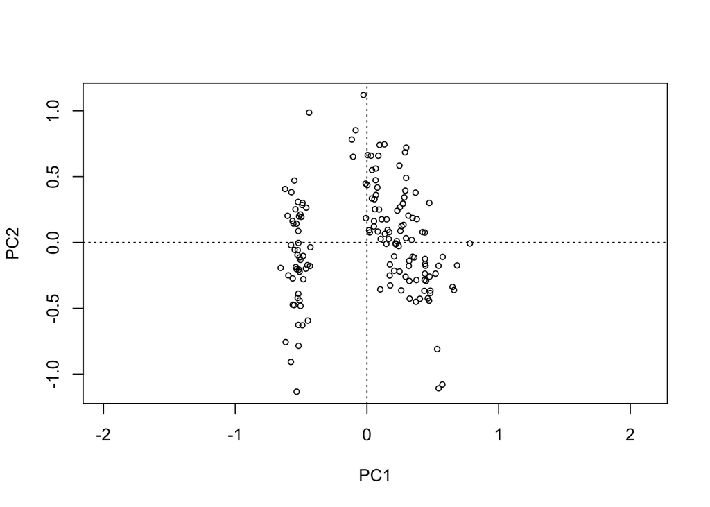

```r
biplot(rda.out, display = "sites")
```

vegan has some nice tools for groups things.

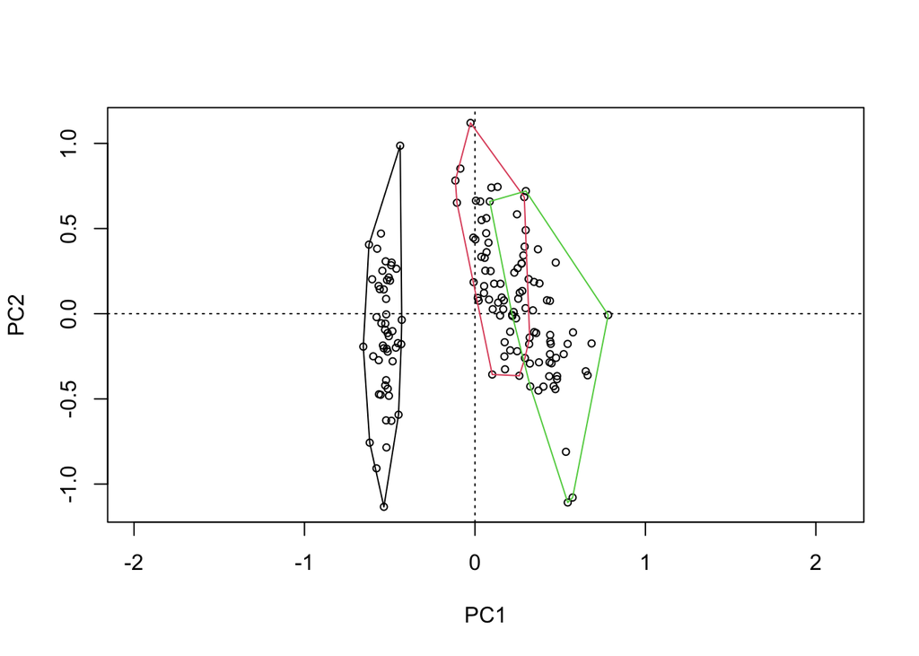

```r
biplot(rda.out, display = "sites")

vegan::ordihull(rda.out,
         group = iris$Species,
         col = 1:3)
```

### Hierachical cluster analysis

Cluster analysis in biology often involves building tree diagrams (dendrograms), which uses hiearchical cluster algorithms.

Hiearchical clustering involves first calculating a distance matrix. There are MANY ways to calculate a distance matrix depending on the data and application. The easiest one to think about is Euclidean distance.

Add row names. Don’t worry about what this is doing

```r
row.names(iris) <- paste(iris$Species,1:nrow(iris),sep = ".")
```

There’s a TON of data here so let’s randomly cut it in half. You should understand this code

```r
i <- 1:nrow(iris)
i <- sample(i, length(i)/2, replace = F)
iris_sub <- iris[i,]
```

```r
dist_euc <- dist(iris_sub[,-5],
                 method = "euclidean")
```

We can then carry out a cluster analysis using the hclust() function. The default function used for calculating branch lenths is called “complete.” Other options allow you to implement UPGMA, WPGMA and other common forms.

```r
clust_euc <- hclust(dist_euc)
```

Plotting the dendrogram results in a very messy graph

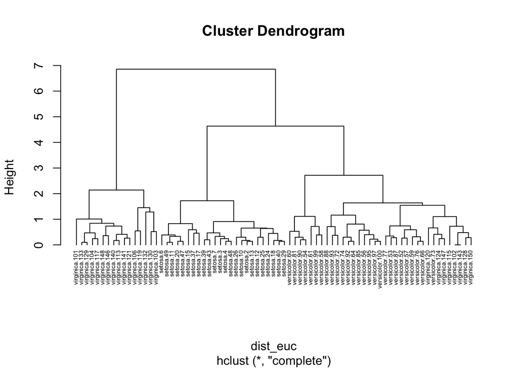

```r
plot(clust_euc, hang = -1, cex = 0.5)
```

It can help in R to plot things horizontally. This requires converting to a different object type.

```r
par(mar = c(1,1,1,1))
is(clust_euc)
```

```
## [1] "hclust"
```

```r
dendro_euc <- as.dendrogram(clust_euc)

is(dendro_euc)
```

```
## [1] "dendrogram"
```

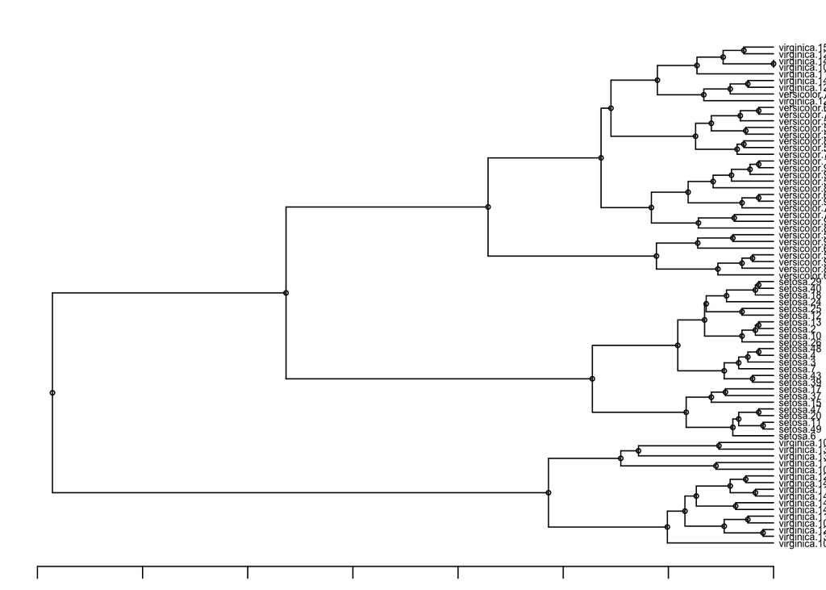

```r
plot(dendro_euc,horiz = T,nodePar = list(pch = c(1,NA),
                                          cex = 0.5,
                                          lab.cex = 0.5))
```

## Task

Generate the cluster diagram and upload it to this assignment

https://canvas.pitt.edu/courses/45284/assignments/460774